# Rental Market

## Notebook Links:

Home

Resale Market

Construction/Starts

Rental Market

Economic Drivers

Demograhics/Migration

## HTML Links:

Home

Resale Market

Construction/Starts

Rental Market

Economic Drivers

Demograhics/Migration

General Rental data - Calgary CMA

## Vacancy Rates

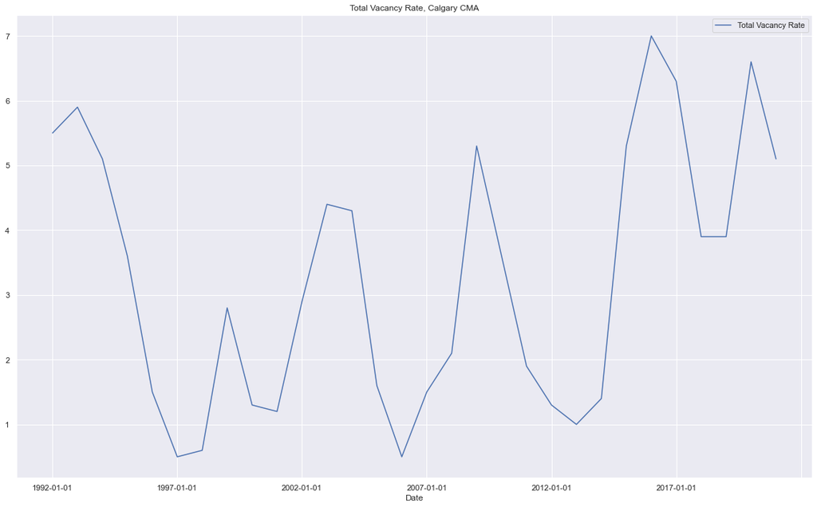

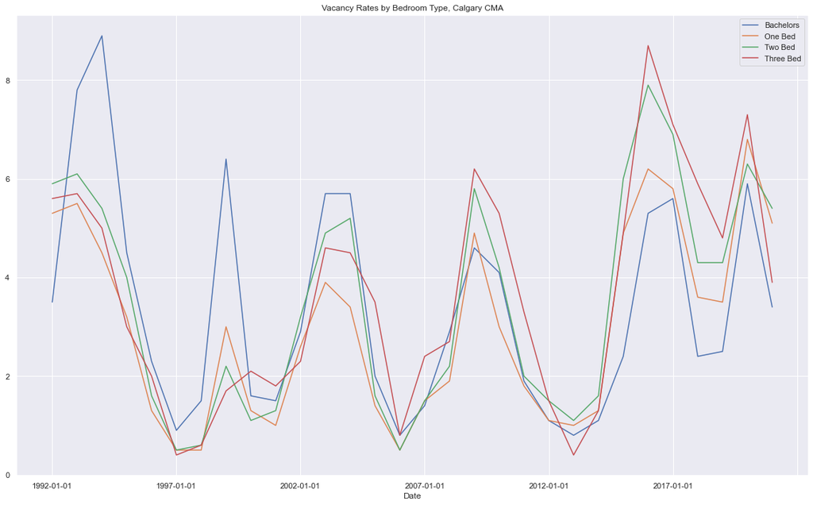

Vacancy rates by bedroom types - note that three bed+ units only regularly had the highest vacancy rates starting in 2005. Before that, bachelor units had the highest vacancy rates across all types. It is important to note however, the majority of the rental universe is in one and two bed units.

## Rental Rates

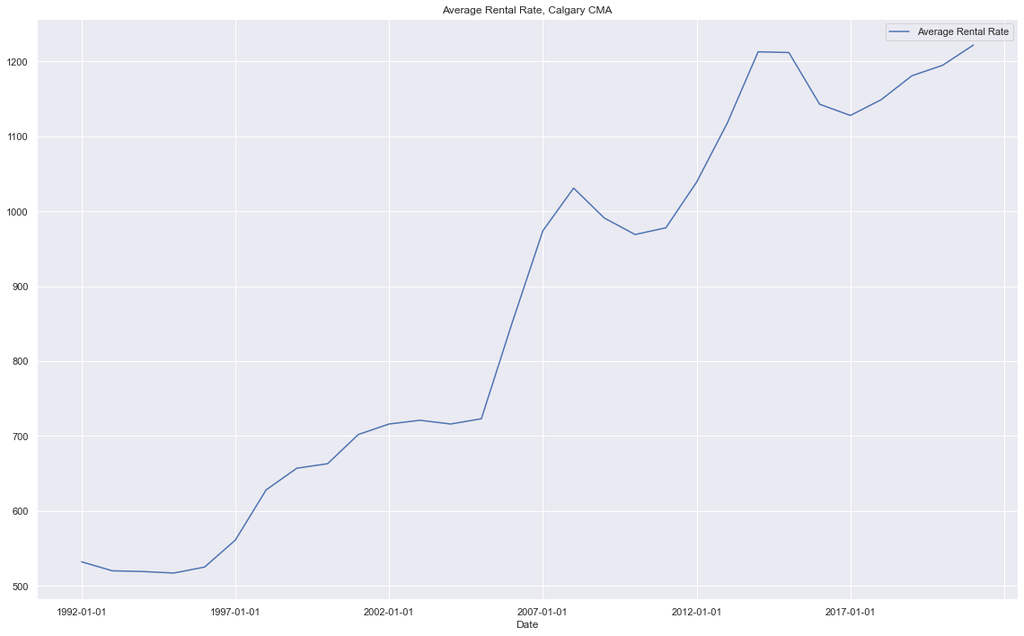

Averge rental rates reflects both increasing home prices, inflation, and the boom-bust cycle. While there is some decreases in average rent during regimes of high vacancy rates, the overall trend is still higher.

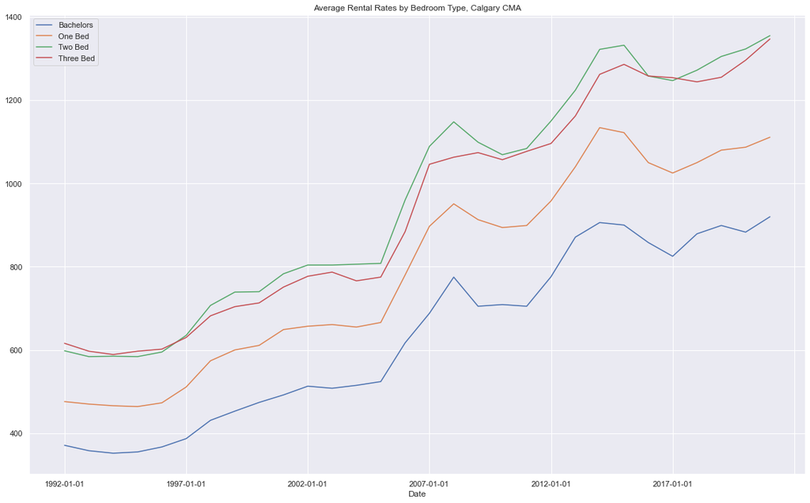

Rental rates across bedrooms, and changes show demand and availability of those units. We can see that while one bed rents haven't reached 2014 levels, 3 bed and 2 bed average rents have surpassed that level in 2021, mainly due to newer units coming on to market.

## Rental Universe

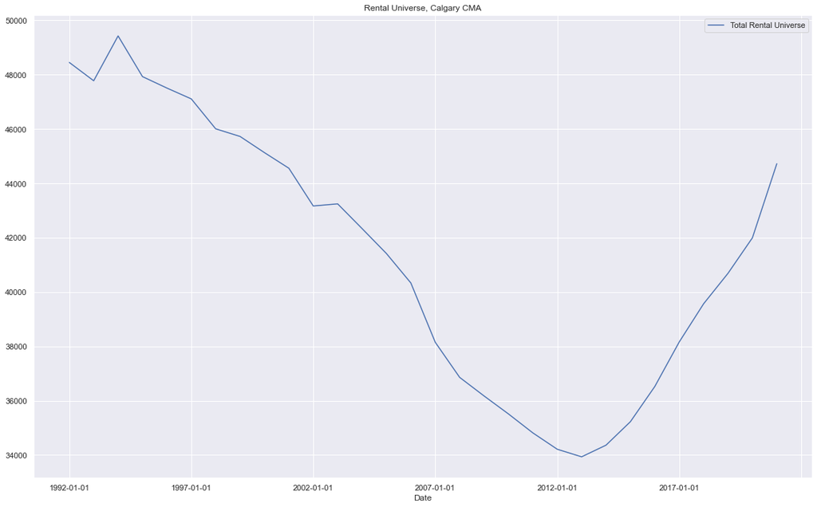

Calgary's rental universe was on a decreasing trend since data was available in the early 1990s. This trend didn't reverse until the early 2010s, in 2013. The increase in rental universe is mainly due to newer developments coming online, as developers catchup to rental demand from the oil boom of the 2000s, and later early 2010s.

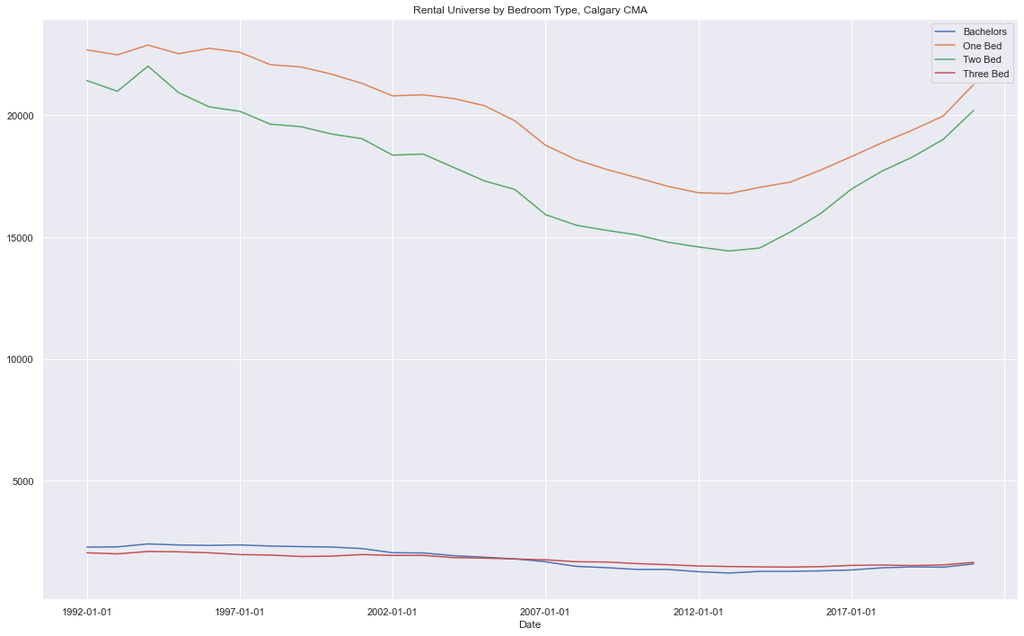

As you can see, the majority of rental stock in Calgary exists as one and two bedroom type units. Two bedroom type units can be seen growing at a faster pace than one-bed room types in recent years, possibly reflecting demand preference, either to live in the inner-city, or to have more space.